# Analyzing Murder in the United States

In this tutorial we will walk through the general workflow that data science follows. But first, let’s load the libraries we need.

```r
library(tidyverse)
library(rvest)
```

## Data Curation

#### Locating Data

There are many different sources of data. In some cases, data is available in an easy-to-use format online. Other times, data must be collected from multiple different sources and combined to create what you were looking for. Luckily, there are many online repositories of datasets that are ready to use. The ones I have found useful are https://www.kaggle.com/ https://data.world/ and https://www.data.gov/ . For more niche topics, there may be a specific site that has what you need.

For this tutorial, I will be using https://ucr.fbi.gov/ which contains a collection of statistics on crime across the United States during the past thirty years.

#### Gathering data

The next step is to get the data into R so that we can work with it. Data comes in many formats. Sometimes it is in an existing database or file that you can directly import into R. Here is a tutorial on importing common data formats into R. https://www.statmethods.net/input/importingdata.html

Other times it is not as easy to collect. In this tutorial, I will be covering how to scrape data from webpages and use it in R.

I will be using the rvest library https://github.com/hadley/rvest which handles the gritty details of scraping and makes it easy to do.

The first step is to locate the data on the webpage you want to scrape. In this example I will be using a HTML table on the FBIâs UCR report. https://ucr.fbi.gov/crime-in-the-u.s/2016/crime-in-the-u.s.-2016/tables/table-12

rvest needs to know what specific element on the webpage we want it to parse. To identify an element, we can use an XPath expression. XPath lets you easily navigate through HTML and identify specific elements. Major web browsers will generate XPath expressions for you which means you donât even need to know how XPath works to be able to use it.

In the image below, I am using Google Chrome to generate an XPath expression to specify a specific HTML table on a web page I want to scrape.

[figure not shown]

Now that we have an URL and a way to specify a specific element, we can use rvest to scrape the page.

First we want to download the webpage and read in the HTML.

```r
html <- read_html('https://www2.fbi.gov/ucr/05cius/data/table_20.html')
```

Then we can select the HTML table using a xpath selector.

```r
table <- html_node(html, xpath='//*[@id="data"]')
```

Then we can parse the table and convert to a data frame.

```r
data <- html_table(table)
head(data)
```

```
##        State Total murders1 Total firearms Handguns Rifles Shotguns
## 1    Alabama            326            223      206      4       12
## 2     Alaska             32             19       15      1        1
## 3    Arizona            440            334      270     22       19
## 4   Arkansas            176            120       74      3       15
## 5 California          2,503          1,845    1,493     83       76
## 6   Colorado            170            109       64      4        3
##   Firearms (type unknown) Knives or cutting instruments Other weapons
## 1                       1                            25            62
## 2                       2                             4             6
## 3                      23                            43            34
## 4                      28                            26            21
## 5                     193                           288           237
## 6                      38                            32            23
##   Hands, fists, feet, etc.2
## 1                        16
## 2                         3
## 3                        29
## 4                         9
## 5                       133
## 6                         6
```

Great! Now we have a data frame we can work with in R.

The FBI puts out a new report on crime every year. We can perform the same operations across multiple years and then combine the data frames into one. With this larger dataset, we can look at how crime has changed over time. In this example, we will collect data on murder by state and type of weapon over the years 2004-2016.

```r
# list of sources of data. vector = (year, page url, xpath of html table)
pages = list(
  c(2004, 'https://www2.fbi.gov/ucr/cius_04/offenses_reported/offense_tabulations/table_20-22.html',
    '//*[@id="table"]/table[1]'),
  c(2005, 'https://www2.fbi.gov/ucr/05cius/data/table_20.html', '//*[@id="data"]'),
  c(2006, 'https://www2.fbi.gov/ucr/cius2006/data/table_20.html', '//*[@id="datatable"]/table'),
  c(2007, 'https://www2.fbi.gov/ucr/cius2007/data/table_20.html', '//*[@id="datatable"]/table'),
  c(2008, 'https://www2.fbi.gov/ucr/cius2008/data/table_20.html', '//*[@id="datatable"]/table'),
  c(2009, 'https://www2.fbi.gov/ucr/cius2009/data/table_20.html', '//*[@id="datatable"]/table'),
  c(2010, 'https://ucr.fbi.gov/crime-in-the-u.s/2010/crime-in-the-u.s.-2010/tables/10tbl20.xls',
    '//*[@id="table-data-container"]/table'),
  c(2011, 'https://ucr.fbi.gov/crime-in-the-u.s/2011/crime-in-the-u.s.-2011/tables/table-20',
    '//*[@id="table-data-container"]/table'),
  c(2012, 'https://ucr.fbi.gov/crime-in-the-u.s/2012/crime-in-the-u.s.-2012/tables/20tabledatadecpdf',
    '//*[@id="table-data-container"]/table'),
  c(2013, 'https://ucr.fbi.gov/crime-in-the-u.s/2013/crime-in-the-u.s.-2013/tables/table-20/table_20_murder_by_state_types_of_weapons_2013.xls',
    '//*[@id="table-data-container"]/table'),
  c(2014, 'https://ucr.fbi.gov/crime-in-the-u.s/2014/crime-in-the-u.s.-2014/tables/table-20',
    '//*[@id="table-data-container"]/table'),
  c(2015, 'https://ucr.fbi.gov/crime-in-the-u.s/2015/crime-in-the-u.s.-2015/tables/table-20',
    '//*[@id="table-data-container"]/table'),
  c(2016, 'https://ucr.fbi.gov/crime-in-the-u.s/2016/crime-in-the-u.s.-2016/tables/table-12',
    '//*[@id="table-data-container"]/table')
)

# take list of sources and convert to list of data frames
tables = map(pages, function(page) {
  # extract data from vector
  year = page[1]
  url = page[2]
  xpath = page[3]

  # get data frame
  table <- read_html(url) %>% # load webpage
    html_node(xpath=xpath) %>% # select html table using xpath selector
    html_table() %>%  # parse html table and convert to data frame
    mutate(year=year) # add year to rows

  # rename columns so they will be uniform across all data frames
  colnames(table) <- c('state','total_murders','total_firearms','handguns','rifles','shotguns','unknown_firearms','knives','other','arms_feet','year')

  # return resulting data frame
  table
})

# merge list of data frames into a single data frame containing all rows
table <- do.call(rbind, tables)

# display columns and a small sample of rows
print(head(table))
```

```
##        state total_murders total_firearms handguns rifles shotguns
## 1    Alabama           247            158      137      0       20
## 2     Alaska            37             17       16      0        1
## 3    Arizona           409            295      244     30       14
## 4   Arkansas           152             95       69      3        6
## 5 California         2,391          1,724    1,442     75       69
## 6   Colorado           199            116       85      5        8
##   unknown_firearms knives other arms_feet year
## 1                1     24    44        21 2004
## 2                0      4    12         4 2004
## 3                7     44    45        25 2004
## 4               17     19    31         7 2004
## 5              138    281   242       144 2004
## 6               18     32    17        34 2004
```

#### Tidying data

Now that we have our data in R, we need to make sure it follows the rules of tidy data.

Rules of tidy data * Each attribute/variable forms a column * Each entity/observation form a row * Each type of entity/observation forms a table

By following these rules, our data will be easier to work with and we will be able to perform analysis more efficiently. You can read more about tidy data and why you might want to follow these rules here: https://cran.r-project.org/web/packages/tidyr/vignettes/tidy-data.html

In the previous section, we collected data from multiple FBI reports. This data is not tidy because it breaks the first rule. We have columns that are values instead of attributes/variables. The columns of the data are: state, total_murders, total_firearms, handguns, rifles, shotguns, unknown_firearms, knives, other, arms_feet, and year. To make this data tidy, we can change the data to be represented by these columns: state, type, count, and year. Each one of these columns represents a specific attribute of the data.

We also need to convert the values of count to actual numeric types. Right now they are just strings. We first want to remove the commas in the strings and then convert them to numbers.

One addition problem is that there is a â3â added to the end of some states that needs to be fixed.

```r
# Collapse the untidy columns into two new tidy columns, type and count. Leave state and year untouched.
tidy_data <- gather(table, type, count, -state, -year) %>%
  transform(count=as.numeric(gsub(",", "", count))) # convert count to a numeric type

# fix state names
tidy_data$state[tidy_data$state=="Alabama3"] <- "Alabama"
tidy_data$state[tidy_data$state=="Illinois3"] <- "Illinois"

# display columns and a small sample of rows
head(tidy_data)
```

```
##        state year          type count
## 1    Alabama 2004 total_murders   247
## 2     Alaska 2004 total_murders    37
## 3    Arizona 2004 total_murders   409
## 4   Arkansas 2004 total_murders   152
## 5 California 2004 total_murders  2391
## 6   Colorado 2004 total_murders   199
```

## Exploratory Data Analysis

Now that we have clean data in R that is ready to work with, we can begin to explore our data. The goal of this is to understand the distribution, spot problems, and think of possible modeling strategies. Here is a great article for more information and why exploratory data analysis is important: https://www.svds.com/value-exploratory-data-analysis/

#### Visualization

To begin exploring our data, we can create some basic graphs to see what our data looks like.

We will start by looking at a plot that shows the total number of murders in the United States each year. This gives us a general understanding of the trend of the number of murders over time. It is important to look at the y axis and notice that it starts around 12000. A scatter plot and fitted line work well to show the change in murders over time.

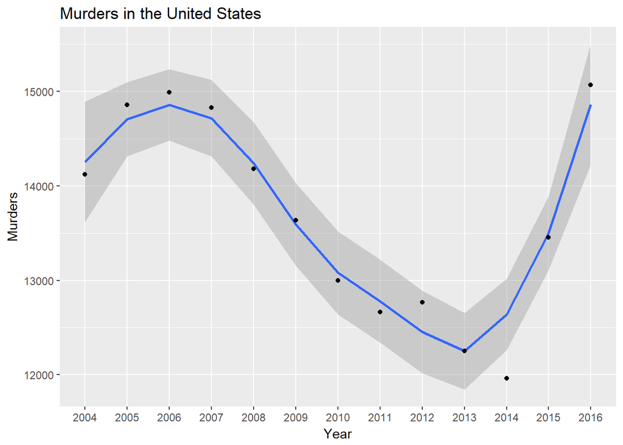

```r
tidy_data %>%
  filter(type=='total_murders') %>% # we are just looking at total murders
  group_by(year) %>% # group the rows together by the year
  summarize(total=sum(count)) %>% # add up all the murders from each row in the groups
  ungroup() %>%
  ggplot(aes(x=year, y=total, group=1)) + # plot the total number of murders vs year
    geom_smooth() +
    geom_point() +
    labs(x="Year", y="Murders", title="Murders in the United States")
```

Next we will construct a plot showing how many murders occurred for different weapons. A bar graph makes it easy to compare each the frequency of each weapon and see that handguns are the largest contributor. It is important to note that this is from the whole interval 2004-2016 which is why the numbers are so large.

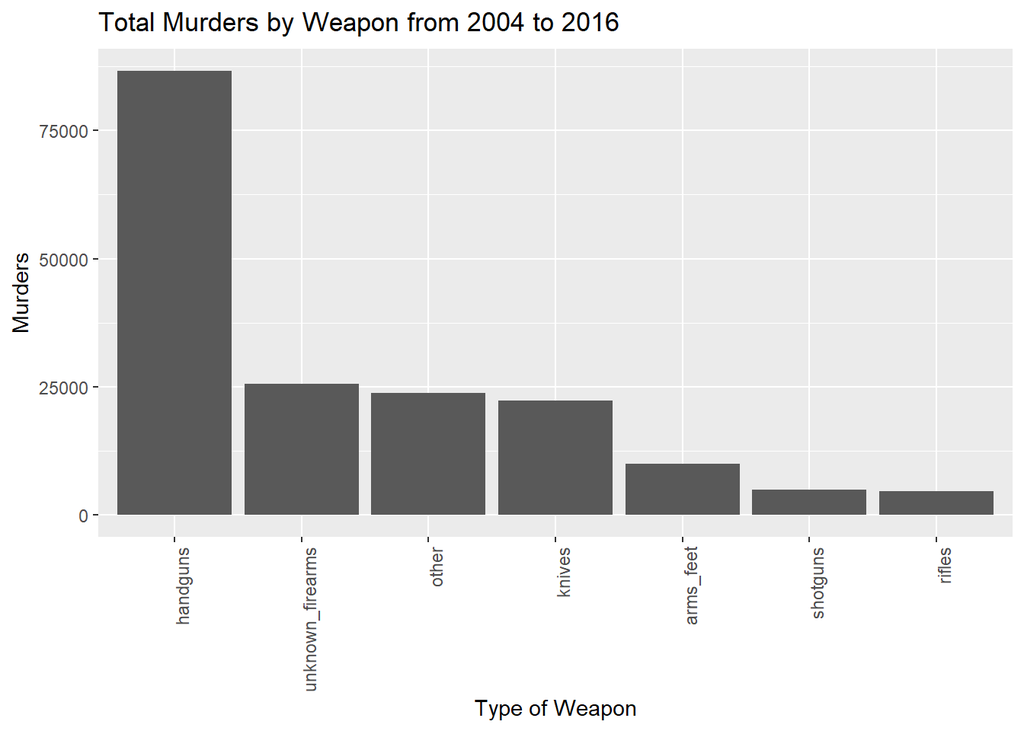

```r
data <- tidy_data %>%
  group_by(type) %>% # group the rows together by type
  filter(!type %in% c('total_murders', 'total_firearms')) %>% # remove rows specifying total counts
  summarize(total=sum(count)) # add up all the murders

data$type <- factor(data$type, levels = data$type[order(-data$total)])

  ggplot(data, aes(x=type, y=total)) + # plot the type of weapon vs number of murders
    geom_bar(stat="identity") +
    labs(x="Type of Weapon", y="Murders", title="Total Murders by Weapon from 2004 to 2016") +
    theme(axis.text.x=element_text(angle=90, hjust=1))
```

We can combine the previous two plots into a single plot. It does a good job of putting the trend from the first plot into proportional by starting the y axis at zero. This plot also lets us compare the growth/reduction of specific murder weapons over time.

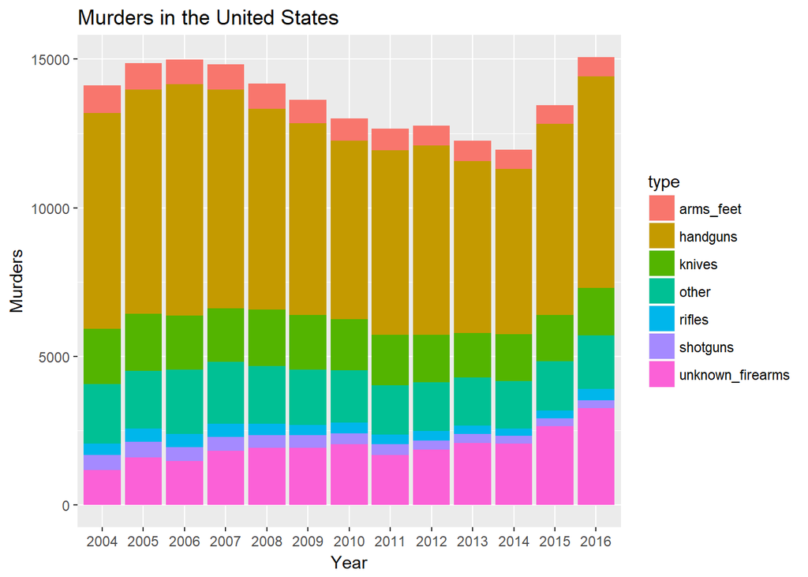

```r
tidy_data %>%
  group_by(year) %>% # group the rows together by the year
  filter(!type %in% c('total_murders', 'total_firearms')) %>% # remove rows specifying total counts
  ggplot(aes(x=year, y=count, fill=type)) + # plot murders by year and fill in  weapon type
    geom_bar(stat="identity") +
    labs(x="Year", y="Murders", title="Murders in the United States")
```

#### Summarization

When summarizing data we are looking to quantify the properties that we saw in our visualizations. The main properties we will look at are central tendency and spread.

Central tendency is a measurement of a typical value in a distribution of data. We will use the arithmetic mean as this measure.

Spread is a measure of how far values in a distribution are from each other. We will use standard deviation as this measure.

$$Mean=\bar{x}=\dfrac{1}{n}\sum_{i=1}^n x_i$$

$$Standard Deviation=\sigma=\sqrt{\dfrac{1}{n}\sum_{i=1}^n (x_i-Mean)^2}$$

Calculating mean and standard deviation in R is simple. We can use the summarize function to do this. Here we are calculating the mean and standard deviation of the number of murders per year in each state.

```r
data <- tidy_data %>%
  filter(type == 'total_murders') %>%
  group_by(state) %>%
  summarize(mean=mean(count), sd=sd(count))
print(data)
```

```
## # A tibble: 54 x 3
##    state                  mean     sd
##    <chr>                 <dbl>  <dbl>
##  1 Alabama               181.  165.
##  2 Alaska                 36.1   9.97
##  3 Arizona               361.   68.3
##  4 Arkansas              168.   22.0
##  5 California           2035   286.
##  6 Colorado              163.   22.6
##  7 Connecticut           104.   21.0
##  8 Delaware               45    12.9
##  9 District of Columbia  127    22.5
## 10 Georgia               561.   50.6
## # ... with 44 more rows
```

#### Data transformation

To make interpretation of data easier, we can transform variables to a common unit-less scale. Right now we have average number of murders in each state per year. To making comparing these values easier, we can convert them to z-scores.

$$z_i=\dfrac{x_i-\bar{x}}{\sigma_x}$$

```r
data <- data %>%
  mutate(z_score=(mean-mean(mean))/sd(mean))
print(data)
```

```
## # A tibble: 54 x 4
##    state                  mean     sd z_score
##    <chr>                 <dbl>  <dbl>   <dbl>
##  1 Alabama               181.  165.    -0.230
##  2 Alaska                 36.1   9.97  -0.647
##  3 Arizona               361.   68.3    0.288
##  4 Arkansas              168.   22.0   -0.269
##  5 California           2035   286.     5.10
##  6 Colorado              163.   22.6   -0.282
##  7 Connecticut           104.   21.0   -0.453
##  8 Delaware               45    12.9   -0.621
##  9 District of Columbia  127    22.5   -0.385
## 10 Georgia               561.   50.6    0.864
## # ... with 44 more rows
```

Just at a glance, the z-score for California is 5.10. It is immediately clear that California has many more murders per year than other states (without having to look through the means from other states) because its value is over 5 standard deviations above the mean.

#### Handling missing data

The FBI data source is complete so there is no missing data. This is unusual as most often, datasets can have missing values.

In the cases where values are missing, a good approach can be to replace missing values with the mean of the dataset. This has the effect of fixing the missing data problem while not changing the mean of the new dataset.

## Analysis

#### Hypothesis testing

Hypothesis testing is a way of investigating claims made about a population using sample data. There are too many different types of tests and procedures to cover in this tutorial, so if you are interested in learning more I suggest you check out this handbook on statistics: http://www.biostathandbook.com/hypothesistesting.html

The question we hope to answer using hypothesis testing: âIs there a difference in the number of murders committed using handguns verses rifles?â

Our initial, or null, hypothesis is that the number of murders committed using handguns is equal to the number of murders committed using rifles. Our alternative hypothesis is that more murders are committed using handguns than rifles.

To test the hypothesis, we will use a paired t-test comparing the number of murders from each state for every year. A paired t-test lets us ignore the differences between states and years and compare rifles and handguns in the same environment.

```r
handguns <- tidy_data %>%
  filter(type == 'handguns') %>%
  arrange(year, state)

rifles <- tidy_data %>%
  filter(type == 'rifles') %>%
  arrange(year, state)

t.test(handguns$count, rifles$count, paired = TRUE, alternative = "greater")
```

```
##
##  Paired t-test
##
## data:  handguns$count and rifles$count
## t = 17.095, df = 653, p-value < 2.2e-16
## alternative hypothesis: true difference in means is greater than 0
## 95 percent confidence interval:
##  113.3851      Inf
## sample estimates:
## mean of the differences
##                125.4755
```

Our p-value is extremely close to zero so we have evidence to reject our null hypothesis in favor of our alternative hypothesis. We can conclude that we are confident that there are more murdered committed using handguns than rifles.

## Conclusion

Congratulations! You have made it to the end of this tutorial. In this tutorial we covered the basics of data science and hopefully you learned something useful. Data science is a diverse field that has many different applications. You now understand the general workflow that data scientists follow and the kinds of things they need to do.